# Risk Factor Analysis

## Outcome Variable

**Outcome Variable:** ever_co

## Predictor Variables

**Intervention Variable:** hhwealth_quart

**Adjustment Set:**

unadjusted

## Stratifying Variables

The analysis was stratified on these variable(s):

- agecat
- studyid
- country

## Data Summary

| agecat | studyid | country | hhwealth_quart | ever_co | n_cell | n |
| --- | --- | --- | --- | --- | --- | --- |
| 0-24 months | COHORTS | GUATEMALA | Wealth Q4 | 0 | 434 | 1263 |
| 0-24 months | COHORTS | GUATEMALA | Wealth Q4 | 1 | 42 | 1263 |
| 0-24 months | COHORTS | GUATEMALA | Wealth Q1 | 0 | 212 | 1263 |
| 0-24 months | COHORTS | GUATEMALA | Wealth Q1 | 1 | 32 | 1263 |
| 0-24 months | COHORTS | GUATEMALA | Wealth Q2 | 0 | 222 | 1263 |
| 0-24 months | COHORTS | GUATEMALA | Wealth Q2 | 1 | 36 | 1263 |
| 0-24 months | COHORTS | GUATEMALA | Wealth Q3 | 0 | 251 | 1263 |
| 0-24 months | COHORTS | GUATEMALA | Wealth Q3 | 1 | 34 | 1263 |
| 0-24 months | COHORTS | PHILIPPINES | Wealth Q4 | 0 | 753 | 3044 |
| 0-24 months | COHORTS | PHILIPPINES | Wealth Q4 | 1 | 87 | 3044 |
| 0-24 months | COHORTS | PHILIPPINES | Wealth Q1 | 0 | 511 | 3044 |
| 0-24 months | COHORTS | PHILIPPINES | Wealth Q1 | 1 | 170 | 3044 |
| 0-24 months | COHORTS | PHILIPPINES | Wealth Q2 | 0 | 439 | 3044 |
| 0-24 months | COHORTS | PHILIPPINES | Wealth Q2 | 1 | 101 | 3044 |
| 0-24 months | COHORTS | PHILIPPINES | Wealth Q3 | 0 | 781 | 3044 |
| 0-24 months | COHORTS | PHILIPPINES | Wealth Q3 | 1 | 202 | 3044 |
| 0-6 months | COHORTS | GUATEMALA | Wealth Q4 | 0 | 363 | 1014 |
| 0-6 months | COHORTS | GUATEMALA | Wealth Q4 | 1 | 6 | 1014 |
| 0-6 months | COHORTS | GUATEMALA | Wealth Q1 | 0 | 190 | 1014 |
| 0-6 months | COHORTS | GUATEMALA | Wealth Q1 | 1 | 5 | 1014 |
| 0-6 months | COHORTS | GUATEMALA | Wealth Q2 | 0 | 200 | 1014 |
| 0-6 months | COHORTS | GUATEMALA | Wealth Q2 | 1 | 2 | 1014 |
| 0-6 months | COHORTS | GUATEMALA | Wealth Q3 | 0 | 242 | 1014 |
| 0-6 months | COHORTS | GUATEMALA | Wealth Q3 | 1 | 6 | 1014 |
| 0-6 months | COHORTS | PHILIPPINES | Wealth Q4 | 0 | 827 | 3043 |
| 0-6 months | COHORTS | PHILIPPINES | Wealth Q4 | 1 | 13 | 3043 |
| 0-6 months | COHORTS | PHILIPPINES | Wealth Q1 | 0 | 658 | 3043 |
| 0-6 months | COHORTS | PHILIPPINES | Wealth Q1 | 1 | 22 | 3043 |
| 0-6 months | COHORTS | PHILIPPINES | Wealth Q2 | 0 | 527 | 3043 |
| 0-6 months | COHORTS | PHILIPPINES | Wealth Q2 | 1 | 13 | 3043 |
| 0-6 months | COHORTS | PHILIPPINES | Wealth Q3 | 0 | 959 | 3043 |
| 0-6 months | COHORTS | PHILIPPINES | Wealth Q3 | 1 | 24 | 3043 |
| 6-24 months | COHORTS | GUATEMALA | Wealth Q4 | 0 | 396 | 1153 |
| 6-24 months | COHORTS | GUATEMALA | Wealth Q4 | 1 | 37 | 1153 |
| 6-24 months | COHORTS | GUATEMALA | Wealth Q1 | 0 | 194 | 1153 |
| 6-24 months | COHORTS | GUATEMALA | Wealth Q1 | 1 | 31 | 1153 |
| 6-24 months | COHORTS | GUATEMALA | Wealth Q2 | 0 | 205 | 1153 |
| 6-24 months | COHORTS | GUATEMALA | Wealth Q2 | 1 | 36 | 1153 |
| 6-24 months | COHORTS | GUATEMALA | Wealth Q3 | 0 | 225 | 1153 |
| 6-24 months | COHORTS | GUATEMALA | Wealth Q3 | 1 | 29 | 1153 |
| 6-24 months | COHORTS | PHILIPPINES | Wealth Q4 | 0 | 690 | 2808 |
| 6-24 months | COHORTS | PHILIPPINES | Wealth Q4 | 1 | 80 | 2808 |
| 6-24 months | COHORTS | PHILIPPINES | Wealth Q1 | 0 | 442 | 2808 |
| 6-24 months | COHORTS | PHILIPPINES | Wealth Q1 | 1 | 164 | 2808 |
| 6-24 months | COHORTS | PHILIPPINES | Wealth Q2 | 0 | 407 | 2808 |
| 6-24 months | COHORTS | PHILIPPINES | Wealth Q2 | 1 | 97 | 2808 |
| 6-24 months | COHORTS | PHILIPPINES | Wealth Q3 | 0 | 733 | 2808 |
| 6-24 months | COHORTS | PHILIPPINES | Wealth Q3 | 1 | 195 | 2808 |

The following strata were considered:

- agecat: 0-24 months, studyid: COHORTS, country: GUATEMALA
- agecat: 0-24 months, studyid: COHORTS, country: PHILIPPINES
- agecat: 0-6 months, studyid: COHORTS, country: GUATEMALA
- agecat: 0-6 months, studyid: COHORTS, country: PHILIPPINES
- agecat: 6-24 months, studyid: COHORTS, country: GUATEMALA
- agecat: 6-24 months, studyid: COHORTS, country: PHILIPPINES

### Dropped Strata

Some strata were dropped due to rare outcomes:

- agecat: 0-6 months, studyid: COHORTS, country: GUATEMALA

## Methods Detail

We’re interested in the causal parameters $E[Y_a]$ for all values of $a \in \mathcal{A}$. These parameters represent the mean outcome if, possibly contrary to fact, we intervened to set all units to have $A=a$. Under the randomization and positivity assumptions, these are identified by the statistical parameters $\psi_a=E_W[E_{Y|A,W}(Y|A=a,W)]$. In addition, we’re interested in the mean of $Y$, $E[Y]$ under no intervention (the observed mean). We will estimate these parameters by using SuperLearner to fit the relevant likelihood factors – $E_{Y|A,W}(Y|A=a,W)$ and $p(A=a|W)$, and then updating our likelihood fit using a joint TMLE.

For unadjusted analyses ($W=\{\}$), initial likelihoods were estimated using Lrnr_glm to estimate the simple $E(Y|A)$ and Lrnr_mean to estimate $p(A)$. For adjusted analyses, a small library containing Lrnr_glmnet, Lrnr_xgboost, and Lrnr_mean was used.

Having estimated these parameters, we will then use the delta method to estimate relative risks and attributable risks relative to a prespecified baseline level of $A$.

# Results Detail

## Results Plots

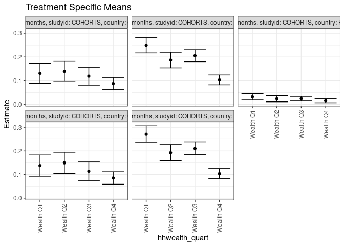

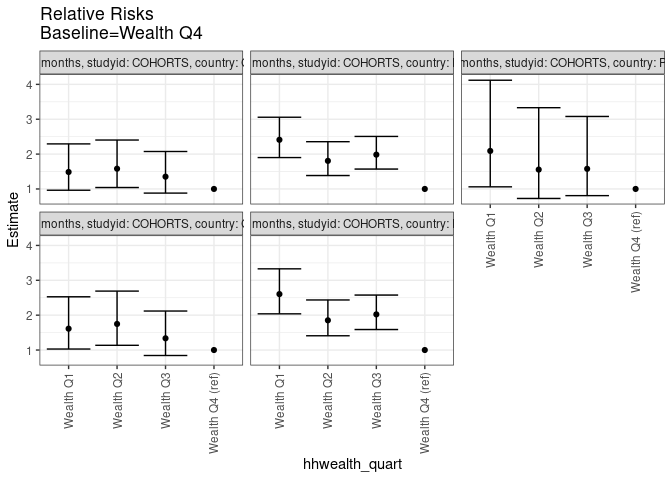

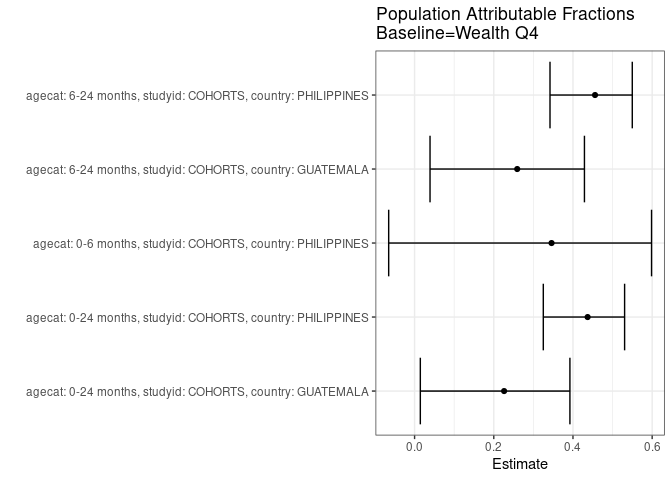

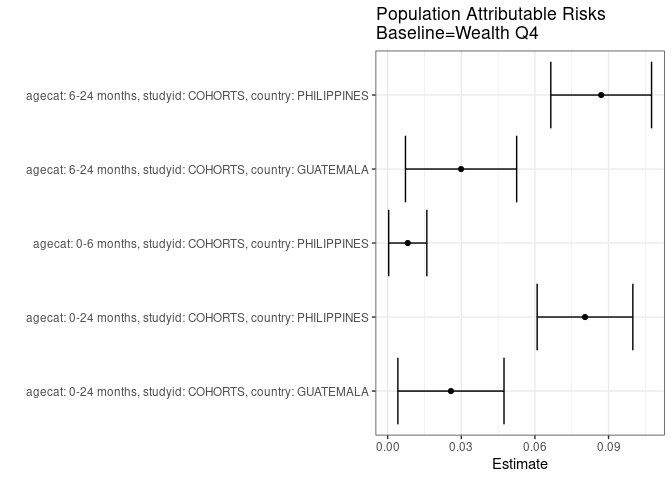

## Results Table

### Parameter: TSM

| agecat | studyid | country | intervention_level | baseline_level | estimate | ci_lower | ci_upper |
| --- | --- | --- | --- | --- | --- | --- | --- |
| 0-24 months | COHORTS | GUATEMALA | Wealth Q4 | NA | 0.0882353 | 0.0627447 | 0.1137258 |
| 0-24 months | COHORTS | GUATEMALA | Wealth Q1 | NA | 0.1311475 | 0.0887756 | 0.1735195 |
| 0-24 months | COHORTS | GUATEMALA | Wealth Q2 | NA | 0.1395349 | 0.0972370 | 0.1818327 |
| 0-24 months | COHORTS | GUATEMALA | Wealth Q3 | NA | 0.1192982 | 0.0816514 | 0.1569451 |
| 0-24 months | COHORTS | PHILIPPINES | Wealth Q4 | NA | 0.1035714 | 0.0829624 | 0.1241805 |
| 0-24 months | COHORTS | PHILIPPINES | Wealth Q1 | NA | 0.2496329 | 0.2171216 | 0.2821441 |
| 0-24 months | COHORTS | PHILIPPINES | Wealth Q2 | NA | 0.1870370 | 0.1541427 | 0.2199314 |
| 0-24 months | COHORTS | PHILIPPINES | Wealth Q3 | NA | 0.2054934 | 0.1802301 | 0.2307567 |
| 0-6 months | COHORTS | PHILIPPINES | Wealth Q4 | NA | 0.0154762 | 0.0071274 | 0.0238250 |
| 0-6 months | COHORTS | PHILIPPINES | Wealth Q1 | NA | 0.0323529 | 0.0190521 | 0.0456538 |
| 0-6 months | COHORTS | PHILIPPINES | Wealth Q2 | NA | 0.0240741 | 0.0111439 | 0.0370043 |
| 0-6 months | COHORTS | PHILIPPINES | Wealth Q3 | NA | 0.0244151 | 0.0147656 | 0.0340645 |
| 6-24 months | COHORTS | GUATEMALA | Wealth Q4 | NA | 0.0854503 | 0.0591081 | 0.1117926 |
| 6-24 months | COHORTS | GUATEMALA | Wealth Q1 | NA | 0.1377778 | 0.0927226 | 0.1828329 |
| 6-24 months | COHORTS | GUATEMALA | Wealth Q2 | NA | 0.1493776 | 0.1043541 | 0.1944011 |
| 6-24 months | COHORTS | GUATEMALA | Wealth Q3 | NA | 0.1141732 | 0.0750463 | 0.1533002 |
| 6-24 months | COHORTS | PHILIPPINES | Wealth Q4 | NA | 0.1038961 | 0.0823406 | 0.1254516 |
| 6-24 months | COHORTS | PHILIPPINES | Wealth Q1 | NA | 0.2706271 | 0.2352477 | 0.3060064 |
| 6-24 months | COHORTS | PHILIPPINES | Wealth Q2 | NA | 0.1924603 | 0.1580362 | 0.2268844 |
| 6-24 months | COHORTS | PHILIPPINES | Wealth Q3 | NA | 0.2101293 | 0.1839129 | 0.2363457 |

### Parameter: E(Y)

| agecat | studyid | country | intervention_level | baseline_level | estimate | ci_lower | ci_upper |
| --- | --- | --- | --- | --- | --- | --- | --- |
| 0-24 months | COHORTS | GUATEMALA | NA | NA | 0.1140143 | 0.0964790 | 0.1315495 |
| 0-24 months | COHORTS | PHILIPPINES | NA | NA | 0.1839685 | 0.1702020 | 0.1977349 |
| 0-6 months | COHORTS | PHILIPPINES | NA | NA | 0.0236609 | 0.0182597 | 0.0290620 |
| 6-24 months | COHORTS | GUATEMALA | NA | NA | 0.1153513 | 0.0969046 | 0.1337979 |
| 6-24 months | COHORTS | PHILIPPINES | NA | NA | 0.1908832 | 0.1763448 | 0.2054216 |

### Parameter: RR

| agecat | studyid | country | intervention_level | baseline_level | estimate | ci_lower | ci_upper |
| --- | --- | --- | --- | --- | --- | --- | --- |
| 0-24 months | COHORTS | GUATEMALA | Wealth Q4 | Wealth Q4 | 1.000000 | 1.0000000 | 1.000000 |
| 0-24 months | COHORTS | GUATEMALA | Wealth Q1 | Wealth Q4 | 1.486339 | 0.9635861 | 2.292689 |
| 0-24 months | COHORTS | GUATEMALA | Wealth Q2 | Wealth Q4 | 1.581395 | 1.0403528 | 2.403811 |
| 0-24 months | COHORTS | GUATEMALA | Wealth Q3 | Wealth Q4 | 1.352047 | 0.8814245 | 2.073950 |
| 0-24 months | COHORTS | PHILIPPINES | Wealth Q4 | Wealth Q4 | 1.000000 | 1.0000000 | 1.000000 |
| 0-24 months | COHORTS | PHILIPPINES | Wealth Q1 | Wealth Q4 | 2.410249 | 1.9001157 | 3.057339 |
| 0-24 months | COHORTS | PHILIPPINES | Wealth Q2 | Wealth Q4 | 1.805875 | 1.3846944 | 2.355165 |
| 0-24 months | COHORTS | PHILIPPINES | Wealth Q3 | Wealth Q4 | 1.984074 | 1.5702791 | 2.506911 |
| 0-6 months | COHORTS | PHILIPPINES | Wealth Q4 | Wealth Q4 | 1.000000 | 1.0000000 | 1.000000 |
| 0-6 months | COHORTS | PHILIPPINES | Wealth Q1 | Wealth Q4 | 2.090498 | 1.0609255 | 4.119216 |
| 0-6 months | COHORTS | PHILIPPINES | Wealth Q2 | Wealth Q4 | 1.555556 | 0.7265744 | 3.330358 |
| 0-6 months | COHORTS | PHILIPPINES | Wealth Q3 | Wealth Q4 | 1.577588 | 0.8082770 | 3.079124 |
| 6-24 months | COHORTS | GUATEMALA | Wealth Q4 | Wealth Q4 | 1.000000 | 1.0000000 | 1.000000 |
| 6-24 months | COHORTS | GUATEMALA | Wealth Q1 | Wealth Q4 | 1.612372 | 1.0286983 | 2.527218 |
| 6-24 months | COHORTS | GUATEMALA | Wealth Q2 | Wealth Q4 | 1.748122 | 1.1358753 | 2.690374 |
| 6-24 months | COHORTS | GUATEMALA | Wealth Q3 | Wealth Q4 | 1.336135 | 0.8426785 | 2.118551 |
| 6-24 months | COHORTS | PHILIPPINES | Wealth Q4 | Wealth Q4 | 1.000000 | 1.0000000 | 1.000000 |
| 6-24 months | COHORTS | PHILIPPINES | Wealth Q1 | Wealth Q4 | 2.604786 | 2.0383190 | 3.328678 |
| 6-24 months | COHORTS | PHILIPPINES | Wealth Q2 | Wealth Q4 | 1.852431 | 1.4085632 | 2.436170 |
| 6-24 months | COHORTS | PHILIPPINES | Wealth Q3 | Wealth Q4 | 2.022495 | 1.5876194 | 2.576489 |

### Parameter: PAR

| agecat | studyid | country | intervention_level | baseline_level | estimate | ci_lower | ci_upper |
| --- | --- | --- | --- | --- | --- | --- | --- |
| 0-24 months | COHORTS | GUATEMALA | Wealth Q4 | NA | 0.0257790 | 0.0041576 | 0.0474003 |
| 0-24 months | COHORTS | PHILIPPINES | Wealth Q4 | NA | 0.0803970 | 0.0609077 | 0.0998864 |
| 0-6 months | COHORTS | PHILIPPINES | Wealth Q4 | NA | 0.0081847 | 0.0004134 | 0.0159560 |
| 6-24 months | COHORTS | GUATEMALA | Wealth Q4 | NA | 0.0299009 | 0.0072513 | 0.0525506 |
| 6-24 months | COHORTS | PHILIPPINES | Wealth Q4 | NA | 0.0869871 | 0.0664644 | 0.1075098 |

### Parameter: PAF

| agecat | studyid | country | intervention_level | baseline_level | estimate | ci_lower | ci_upper |
| --- | --- | --- | --- | --- | --- | --- | --- |
| 0-24 months | COHORTS | GUATEMALA | Wealth Q4 | NA | 0.2261029 | 0.0144903 | 0.3922773 |
| 0-24 months | COHORTS | PHILIPPINES | Wealth Q4 | NA | 0.4370153 | 0.3250675 | 0.5303949 |
| 0-6 months | COHORTS | PHILIPPINES | Wealth Q4 | NA | 0.3459160 | -0.0654222 | 0.5984448 |
| 6-24 months | COHORTS | GUATEMALA | Wealth Q4 | NA | 0.2592162 | 0.0390123 | 0.4289618 |
| 6-24 months | COHORTS | PHILIPPINES | Wealth Q4 | NA | 0.4557085 | 0.3419952 | 0.5497704 |